# BUA 345 - Lecture 22 - Intro to Forecasting

Penelope Pooler Eisenbies

2023-04-18

### Setup Chunk for Lecture 22

```r
# this line specifies options for default options for all R Chunks
knitr::opts_chunk$set(echo=T, highlight=T)
# suppress scientific notation
options(scipen=100)

# install helper package that loads and installs other packages, if needed
if (!require("pacman")) install.packages("pacman", repos = "http://lib.stat.cmu.edu/R/CRAN/")
```

```r
# install and load required packages
pacman::p_load(pacman,tidyverse, magrittr, knitr, gridExtra, forecast, tidyquant, lubridate, maps, usdata, mapproj, ggthemes, RColorBrewer, dygraphs)

# verify packages - it's a long list
p_loaded()
```

```
##  [1] "dygraphs"             "RColorBrewer"         "ggthemes"
##  [4] "mapproj"              "usdata"               "maps"
##  [7] "tidyquant"            "quantmod"             "TTR"
## [10] "PerformanceAnalytics" "xts"                  "zoo"
## [13] "forecast"             "gridExtra"            "knitr"
## [16] "magrittr"             "lubridate"            "forcats"
## [19] "stringr"              "dplyr"                "purrr"
## [22] "readr"                "tidyr"                "tibble"
## [25] "ggplot2"              "tidyverse"            "pacman"
```

#### Cross-Sectional Data

- Shows a Snapshot of One Time Period

```r
gsb23 <- read_csv("gsb_23.csv", show_col_types = F, skip=25,
                  col_select = c(1,2,6), ) |>
  slice(1:5) |>
  rename("city" = "...1",
         "2022-23" = "...2",
         "Most" = "...6") |>

  mutate(Most = substr(Most, 1,5) |> as.numeric())
```

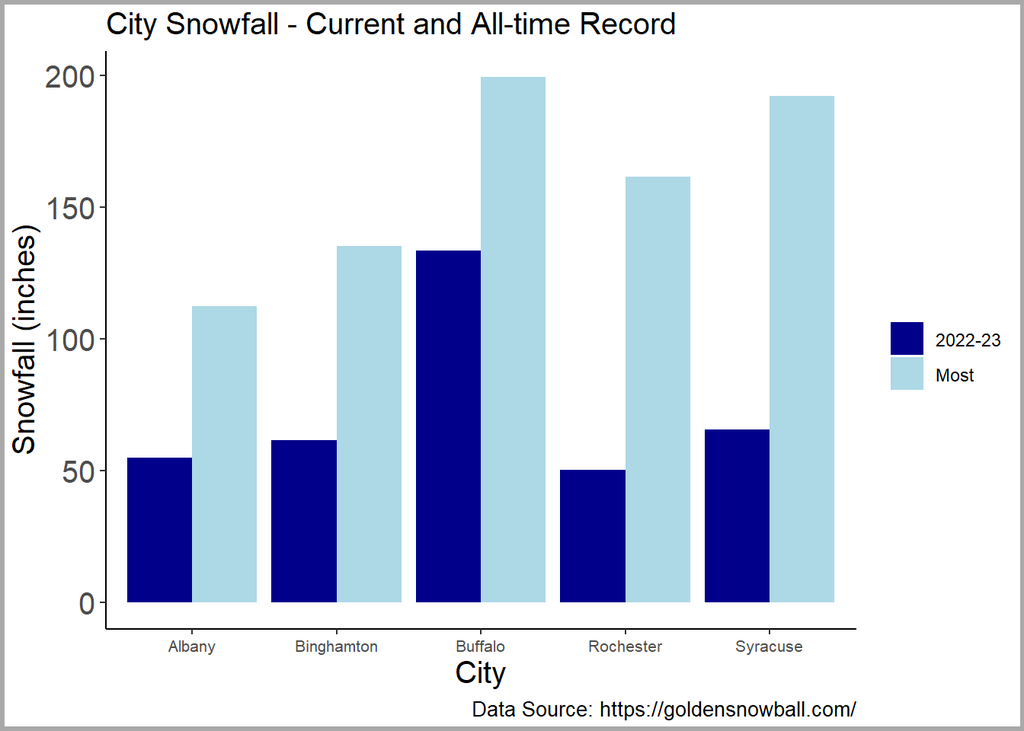

```r
gsb_long <- gsb23 |> pivot_longer(cols = `2022-23`:Most,
                               names_to = "type",
                               values_to = "inches")
(gsb_plt <- gsb_long |>
  ggplot() +
  geom_bar(aes(x=city, y=inches, fill=type),
                stat="identity", position="dodge") +
  scale_fill_manual(values=c("blue4", "lightblue")) +
  theme_classic() +
  labs(fill="", x="City", y="Snowfall (inches)",
       caption="Data Source: https://goldensnowball.com/",
       title="City Snowfall - Current and All-time Record")+
  theme(plot.title = element_text(size = 15),
        plot.caption = element_text(size = 10),
        axis.title.x = element_text(size = 15),
        axis.title.y = element_text(size = 15),
        axis.text.x = element_text(size = 8),
        axis.text.y = element_text(size = 15),
         plot.background =
          element_rect(colour = "darkgrey", fill=NA, size=2)))
```

#### Time Series Data

- Shows Trend over Time

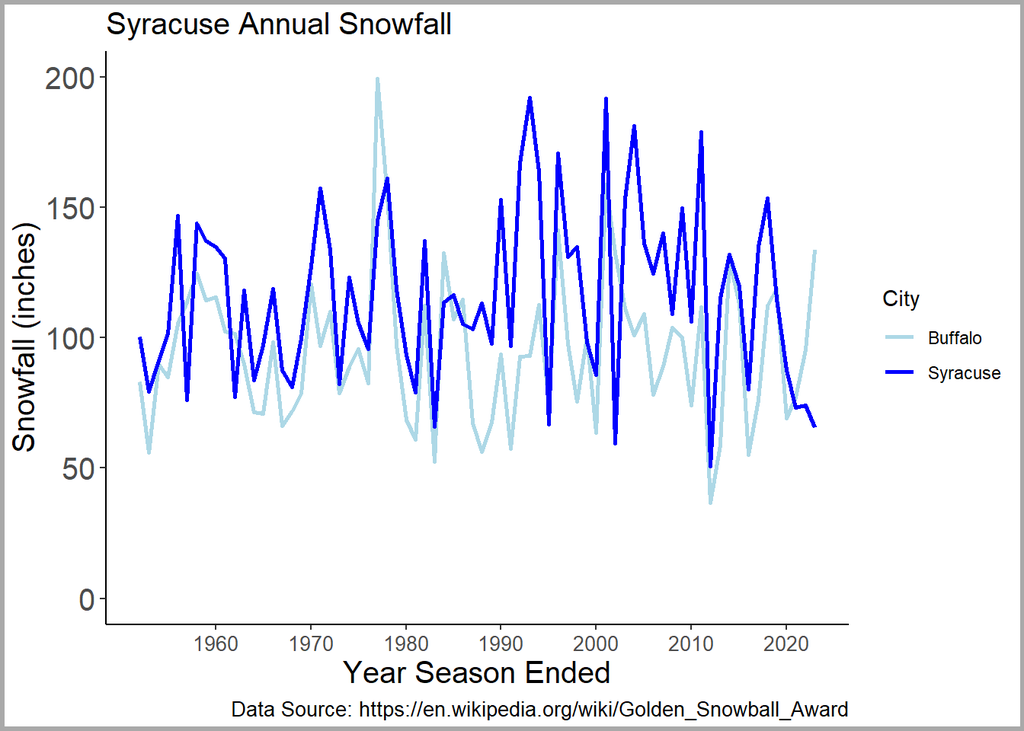

```r
snowfall <- read_csv("snowfall_upstateny_cities.csv",
                     show_col_types = F) |>
  filter(!Season=="Season") |>
  separate(Season, into=c("Season_Start", "Season_End"), sep = "-") |>
  mutate(Season_Start = Season_Start |> as.integer(),
         Season_End = Season_Start + 1 |> as.integer(),
         Syracuse = Syracuse |> as.numeric(),
         Buffalo = Buffalo |> as.numeric()) |>
  rename("city_most" = "City With Most Snow") |>
  select(Season_End, Syracuse, Buffalo, city_most) |>
  filter(Season_End >= 1952) |>
  pivot_longer(cols=Syracuse:Buffalo, names_to = "City", values_to = "Snowfall")

(line_plot <- snowfall |>
  ggplot() +
  geom_line(aes(x=Season_End, y=Snowfall, color=City), linewidth=1) +
  theme_classic() +
  scale_x_continuous(breaks=seq(1960, 2020, 10)) +
  scale_color_manual(values=c("lightblue", "blue")) +
  ylim(0,200) +

  labs(title="Syracuse Annual Snowfall",
       y="Snowfall (inches)",
       x="Year Season Ended",
       caption="Data Source: https://en.wikipedia.org/wiki/Golden_Snowball_Award") +
  theme(plot.title = element_text(size = 15),
        plot.caption = element_text(size = 10),
        axis.title.x = element_text(size = 15),
        axis.title.y = element_text(size = 15),
        axis.text.x = element_text(size = 10),
        axis.text.y = element_text(size = 15),
         plot.background =
          element_rect(colour = "darkgrey", fill=NA, size=2)))
```

### U.S. Population - Cross-Sectional Data

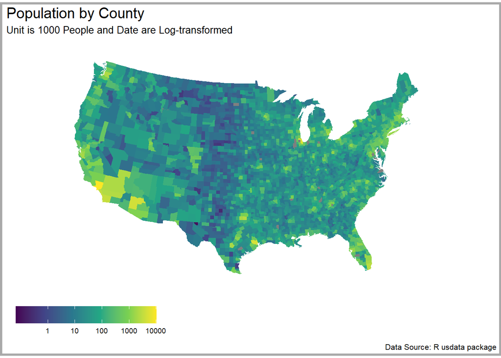

```r
us_counties <- map_data("county") |>                 # county polygons
  rename("state" = "region", "county" = "subregion")
# unique(us_counties$county[us_counties$state=="louisiana"])   # note issue Louisiana counties
cnty2019_all <- county_2019
# unique(cnty2019_all$name[cnty2019_all$state=="Louisiana"]) # note issue Louisiana counties

cnty2019_all <- cnty2019_all |>
  mutate(state = tolower(state),
         county = tolower(name),
         county = gsub(" county", "", county),
         county = gsub(" parish", "", county),
         county = gsub("\\.", "", county))            # \\ is required because . used in R coding

cnty2019_all <- full_join(us_counties,cnty2019_all)   |>
  select(long:county, pop) |>
  mutate(pop1k = pop/1000)
# plot of logged data
# transformation and breaks statement added
(cnty_lpop <- cnty2019_all |>
  ggplot(aes(x=long, y=lat, group=group, fill=pop1k)) +
    geom_polygon() +
    theme_map() +
    coord_map("albers", lat0 = 39, lat1 = 45) +
    labs(fill= "", title="Population by County",
         subtitle="Unit is 1000 People and Date are Log-transformed",
         caption="Data Source: R usdata package") +
    scale_fill_continuous(type = "viridis",trans="log",
                          breaks=c(1,10,100,1000,10000)) +
    theme(legend.position = "bottom",
          legend.key.width = unit(1, "cm"),
          plot.title = element_text(size = 15),
          plot.subtitle = element_text(size = 10),
          plot.caption = element_text(size = 8),
         plot.background = element_rect(colour = "darkgrey", fill=NA, size=2)))
```

### U.S. Population - Time Series Data

- [U.S. Population 1950 - 2023](https://www.macrotrends.net/countries/USA/united-states/population)

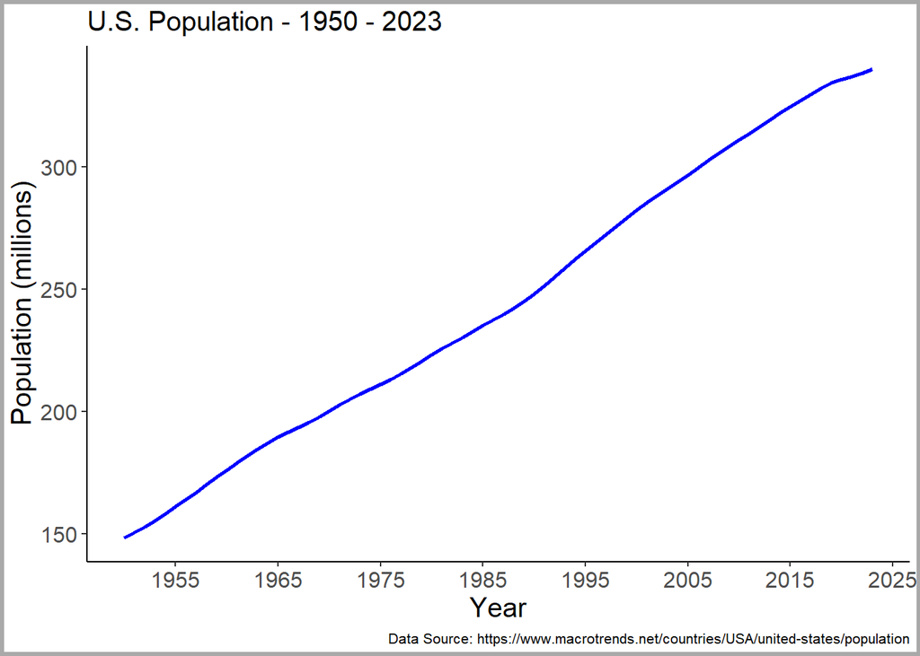

```r
uspop <- read_csv("pop_trend_1950_2023.csv", show_col_type = F) |>
  select(Time, Value) |>
  rename("Year" = "Time", "Population" = "Value") |>
  mutate(popM = Population/1000000)

 (pop_plt <- uspop |>
  ggplot() +
  geom_line(aes(x=Year, y=popM), color="blue", size=1) +
  theme_classic() +
  scale_x_continuous(breaks=seq(1945, 2025, 10)) +

  labs(title="U.S. Population - 1950 - 2023", y="Population (millions)",
       caption="Data Source: https://www.macrotrends.net/countries/USA/united-states/population") +
  theme(plot.title = element_text(size = 15),
        plot.caption = element_text(size = 8),
        axis.title.x = element_text(size = 15),
        axis.title.y = element_text(size = 15),
        axis.text.x = element_text(size = 12),
        axis.text.y = element_text(size = 12),
         plot.background = element_rect(colour = "darkgrey", fill=NA, size=2)))
```

### U.S. Population - Interactive Plot

```r
# convert to xts (extensible time series)
uspop <- uspop |>
  mutate(date=ym(paste(Year,12)))
uspop_xts <- xts(x=uspop[,3], order.by= uspop$date)

# create interactive plot
dygraph(uspop_xts, main="US Population 1950 - 2023") |>
  dySeries("popM", label="Pop. (Mill.)", color= "darkmagenta") |>
  dyAxis("y", label = "", drawGrid = FALSE) |>
  dyAxis("x", label = "", drawGrid = FALSE) |>
  dyShading(from="2020-3-12", to="2021-6-14", color = "lightgrey") |>
  dyRangeSelector()
```

[interactive chart not shown]

### U.S. Population - Modeling Time Series Data

#### Population Trend Forecast

- Create time series using population data
  - Specify `freq = 1` - one observation per year
  - Specify `start = 1950` - first year in dataset
- Model data using `auto.arima` function
  - Specify `ic = aic` - `aic` is the information criterion used to determine model.
  - Specify `seasonality = F` - no seasonal (repeating) pattern in the data.
- This chunk will create and save the model.

```r
# create time series for forecast
pop_ts <- ts(uspop$popM, freq=1, start=1950)

# model data using auto.arima function
pop_model <- auto.arima(pop_ts, ic="aic", seasonal=F)
```

### U.S. Population - Create and Plot Forecasts

**Create forecasts (until 2040)**

```r
# create forecasts (until 2040)
pop_forecast <- forecast(pop_model, h=17)
```

### U.S. Population - Create and Plot Forecasts

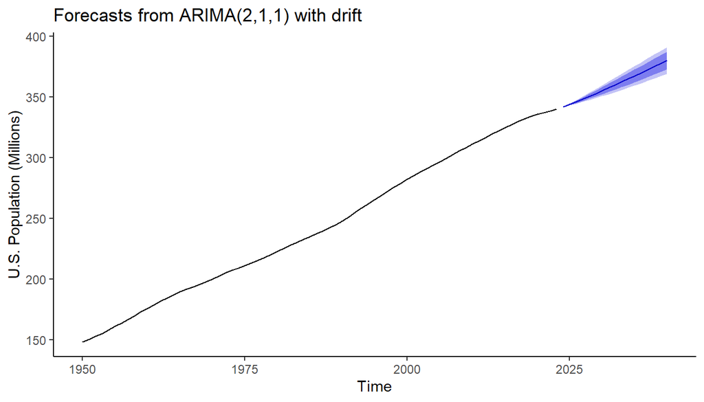

```r
autoplot(pop_forecast) +
  labs(y = "U.S. Population (Millions)") +
  theme_classic()
```

### U.S. Population - Examine Numerical Forecasts

- Point Forecast is the forecasted estimate for each future time period
- Lo 80 and Hi 80 are the lower and upper bounds for the 80% prediction interval
- Lo 95 and Hi 95 are the lower and upper bounds for the 95% prediction interval

```r
# print out forecasts
pop_forecast
```

```
##      Point Forecast    Lo 80    Hi 80    Lo 95    Hi 95
## 2024       341.9140 341.7513 342.0767 341.6651 342.1628
## 2025       343.9589 343.4408 344.4770 343.1666 344.7513
## 2026       346.0985 345.1393 347.0576 344.6316 347.5654
## 2027       348.3135 346.8715 349.7555 346.1081 350.5189
## 2028       350.5901 348.6479 352.5323 347.6198 353.5604
## 2029       352.9173 350.4718 355.3628 349.1772 356.6574
## 2030       355.2861 352.3424 358.2297 350.7841 359.7880
## 2031       357.6891 354.2573 361.1208 352.4407 362.9375
## 2032       360.1203 356.2134 364.0271 354.1452 366.0953
## 2033       362.5746 358.2071 366.9422 355.8950 369.2542
## 2034       365.0481 360.2350 369.8611 357.6872 372.4090
## 2035       367.5372 362.2940 372.7804 359.5184 375.5560
## 2036       370.0393 364.3810 375.6977 361.3856 378.6930
## 2037       372.5520 366.4931 378.6109 363.2858 381.8183
## 2038       375.0735 368.6281 381.5190 365.2161 384.9310
## 2039       377.6022 370.7836 384.4209 367.1740 388.0304
## 2040       380.1369 372.9576 387.3161 369.1572 391.1166
```

### U.S. Population - Examine Residuals and Model Fit

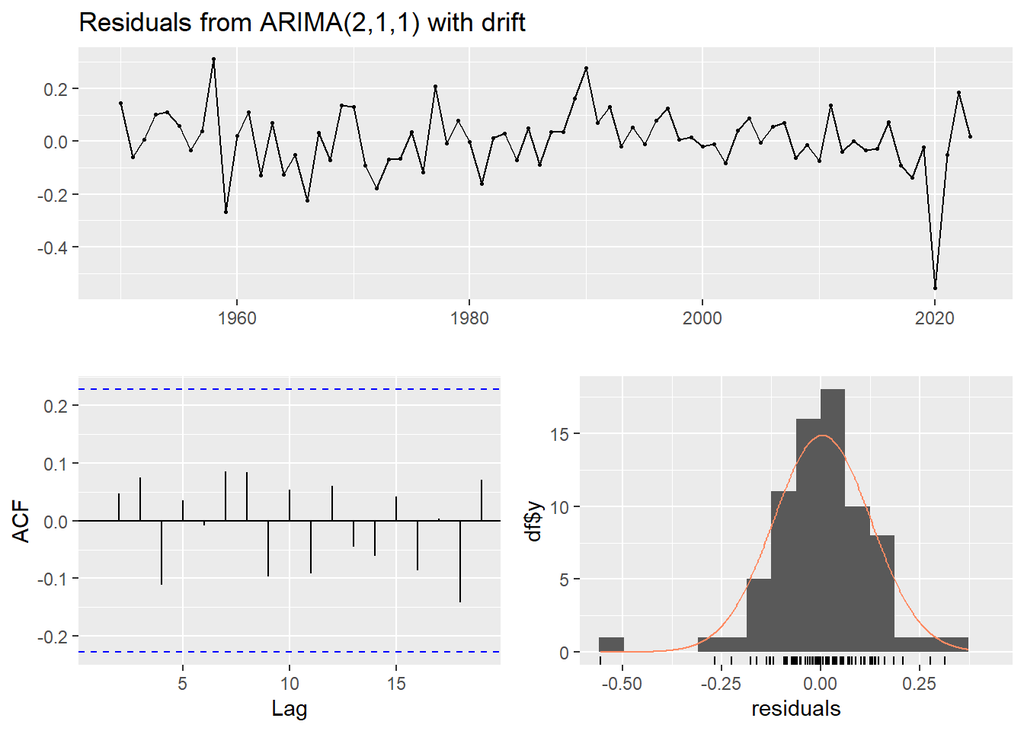

```
##
##  Ljung-Box test
##
## data:  Residuals from ARIMA(2,1,1) with drift
## Q* = 4.0205, df = 7, p-value = 0.7774
##
## Model df: 3.   Total lags used: 10
```

```r
# examine residuals
checkresiduals(pop_forecast)
```

### U.S. Population - Examine Residuals and Model Fit

```r
# examine model accuracy (fit)
(acr <- accuracy(pop_forecast))
```

```
##                       ME      RMSE        MAE         MPE       MAPE       MASE
## Training set 0.003634768 0.1225348 0.08670311 0.002881143 0.03850658 0.03301425
##                      ACF1
## Training set 0.0004401032
```

### Example 2: Netflix Stock Prices - Data from [Yahoo Finance](https://finance.yahoo.com/)

```r
# import from yahoo finance and plot dygraph
getSymbols("NFLX", from = "2010-01-01", to = "2023-04-17")
```

```
## [1] "NFLX"
```

```r
# create interactive plot
(nflx_dg <- dygraph(NFLX[,c(2,3,6)], main="Netflix Stock price") |>
  dySeries("NFLX.Adjusted", label="Adj. Close", color= "purple") |>
  dySeries("NFLX.Low", label="Low", color= "blue") |>
  dySeries("NFLX.High", label="High", color= "red") |>
  dyAxis("y", label = "", drawGrid = FALSE) |>
  dyAxis("x", label = "", drawGrid = FALSE) |>
  dyShading(from="2020-3-12", to="2021-6-14", color = "lightgrey") |>
  dyRangeSelector())
```

[interactive chart not shown]

### Netflix Stock

- Was mostly trending upward, but had a downturn and then another recent upturn.
- Data imported are daily adjusted close
- Data we will use are monthly adjusted close (1st day of trading for each month)

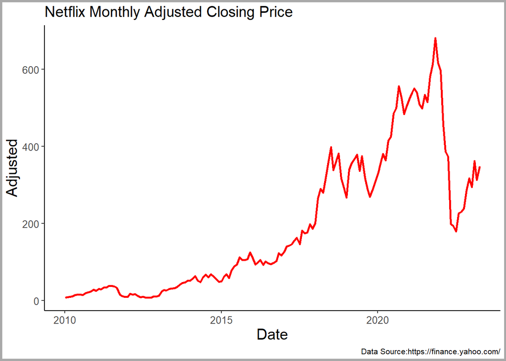

```r
# convert xts to tibble
nflx <- NFLX |>
  fortify.zoo() |> as_tibble(.name_repair = "minimal") |>
  rename("Date" = "Index", "Adjusted" = "NFLX.Adjusted") |>
  mutate(year=year(Date), month=month(Date), day=day(Date)) |>
  group_by(year, month) |>
  filter(day == min(day, na.rm=T)) |>
  ungroup() |>
  select(Date, Adjusted)

(nflx_plot <- nflx |>
  ggplot() +

  geom_line(aes(x=Date, y=Adjusted), color="red", size=1) +

  theme_classic() +

  labs(title="Netflix Monthly Adjusted Closing Price",
       x="Date", Y="Adjusted Closing Price",
       caption = "Data Source:https://finance.yahoo.com/") +

  theme(plot.title = element_text(size = 15),
        plot.caption = element_text(size = 8),
        axis.title.x = element_text(size = 15),
        axis.title.y = element_text(size = 15),
        axis.text.x = element_text(size = 10),
        axis.text.y = element_text(size = 10),
         plot.background = element_rect(colour = "darkgrey", fill=NA, size=2)))
```

### Netflix Stock

- **Forecast Questions:**
  - What will be the estimated stock price be in April of 2024?
  - What ARIMA model was chosen (p,d,q)?

–

- **Model Assessment Questions:**
  - How valid is our model?
    - Check residual plots.
  - How are accurate are our estimates?
    - Examine Prediction Intervals and Prediction Bands
    - Check fit statistics

### Netflix Stock - Modeling Time Series Data

#### Stock Trend Forecast

- Creat time series using Netflix Stock data
  - Specify `freq = 12` - 12 observations per year
  - Specify `start = c(2010, 1)` - first obs. in dataset is January 2010
- Model data using `auto.arima` function
  - Specify `ic = aic` - `aic` is the information criterion used to determine model.
  - Specify `seasonality = F` - no seasonal (repeating) pattern in the data.

–

- This chunk will create and save the model.

```r
# create time series for forecast
nflx_ts <- ts(nflx$Adjusted, freq=12, start=c(2010,1))

# model data using auto.arima function
nflx_model <- auto.arima(nflx_ts, ic="aic", seasonal=F)
```

### Netflix Stock - Create and Plot Forecasts

[figure not shown]

```r
# create forecasts (until April 2023)
nflx_forecast <- forecast(nflx_model, h=12)
```

### Netflix Stock - Create and Plot Forecasts

[figure not shown]

- Darker purple: 80% Prediction Interval Bounds
- Lighter purple: 95% Prediction Interval Bounds
- Plot shows:
  - Lags (`p = 2`), Differencing (`d = 1`), Moving Average (`q = 2`)

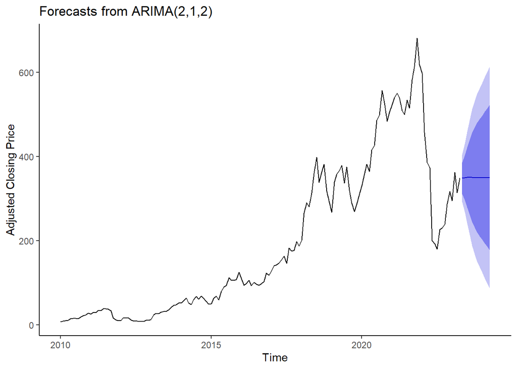

```r
autoplot(nflx_forecast) +
  labs(y = "Adjusted Closing Price") +
  theme_classic()
```

### Netflix Stock - Examine Numerical Forecasts

[figure not shown]

- Point Forecast is the forecasted estimate for each future time period
- Lo 80 and Hi 80 are the lower and upper bounds for the 80% prediction interval
- Lo 95 and Hi 95 are the lower and upper bounds for the 95% prediction interval

```r
# print out forecasts
nflx_forecast
```

```
##          Point Forecast    Lo 80    Hi 80     Lo 95    Hi 95
## May 2023       348.2461 311.5672 384.9251 292.15049 404.3418
## Jun 2023       349.1394 296.1814 402.0974 268.14712 430.1317
## Jul 2023       350.0062 279.1622 420.8502 241.65965 458.3527
## Aug 2023       350.3343 260.8775 439.7912 213.52195 487.1467
## Sep 2023       350.1659 244.1460 456.1857 188.02249 512.3092
## Oct 2023       349.8242 230.4456 469.2028 167.25038 532.3980
## Nov 2023       349.5931 219.5057 479.6805 150.64159 548.5446
## Dec 2023       349.5630 210.2747 488.8512 136.54002 562.5859
## Jan 2024       349.6623 201.7583 497.5663 123.46265 575.8620
## Feb 2024       349.7733 193.4022 506.1445 110.62427 588.9224
## Mar 2024       349.8237 185.1139 514.5335  97.92176 601.7257
## Apr 2024       349.8100 177.0514 522.5687  85.59843 614.0216
```

### Lecture 18 In-class Exercises - Session ID: bua345s23**

#### **Question 3 (L22) - Interpretation of netflix Prediction Intervals

In January of 2024, the Netflix stock price is forecasted to be approximately $350 However the 95% prediction interval indicates it may be as low as `____`.

**How to input your answer:**

- Round to closest whole dollar.
- Don’t include dollar sign.

### Netflix Stock - Examine Residuals and Model Fit

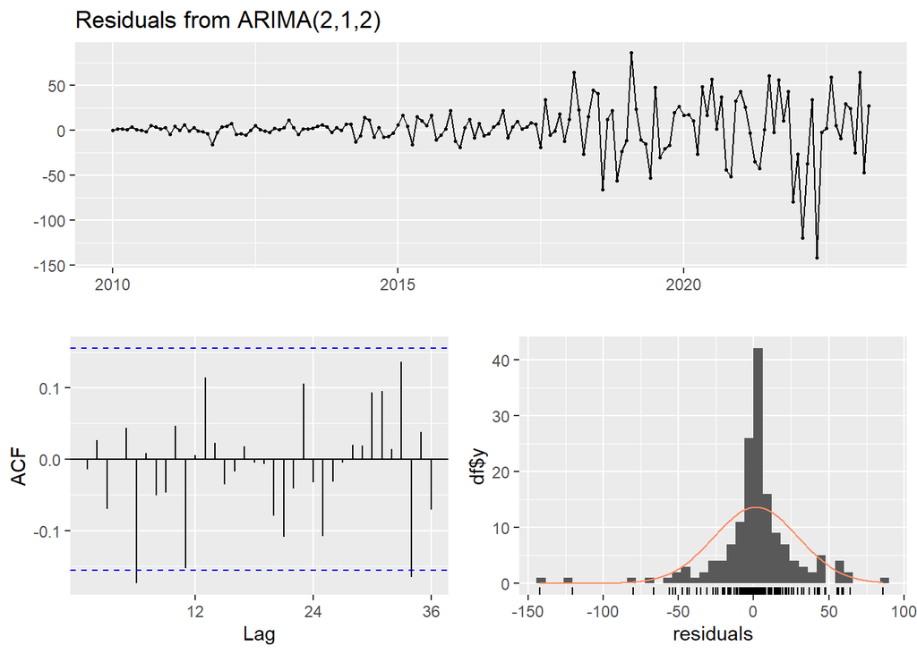

```
##
##  Ljung-Box test
##
## data:  Residuals from ARIMA(2,1,2)
## Q* = 20.308, df = 20, p-value = 0.4388
##
## Model df: 4.   Total lags used: 24
```

```r
# examine residuals
checkresiduals(nflx_forecast)
```

#### Examining Residuals:

- Top Plot: Spikes get larger over time
- ACF: auto-correlation function.
  - Ideally, all or most values are with dashed lines
- Histogram: Distribution of residuals should be approx. normal
  - Appears okay
- Assessment: Stock prices are very volatile and this is sufficient. ]

### Netflix Stock - Examine Residuals and Model Fit

```r
# examine model accuracy (fit)
(acr <- accuracy(nflx_forecast))
```

```
##                    ME  RMSE      MAE      MPE     MAPE      MASE        ACF1
## Training set 1.523401 28.17 17.37481 1.182444 11.90013 0.2273161 -0.01427174
```

–

#### Fit Statistics for Model Comparisons

- Many options for comparing models
- **For BUA 345:** We will use MAPE = Mean Absolute Percent Error
  - **100 – MAPE = Percent accuracy of model.**
- Despite increasing volatility, our stock price model is estimated to be 88.1% accurate.
- This doesn’t guarantee that forecasts will be 88% accurate but it does improve our chances of accurate forecasting.

### Key Points from Today

You may submit an ‘Engagement Question’ about each lecture until midnight on the day of the lecture. **A minimum of four submissions are required during the semester.**